# House Price Prediction Analysis

**Authors**: Dulce Ximena Cid Sanabria & Sikandar Shrestha

This dataset provides key features for predicting house prices, including area, bedrooms, bathrooms, stories, amenities like air conditioning and parking, and information on furnishing status. It enables analysis and modelling to understand the factors impacting house prices and develop accurate predictions in real estate markets.

**NOTE:-** For final Report, Professor Dengdeng Yu suggested us in the presentation day that work on some new dataset ( we have taken **“Housing.csv”**). Because of the model is not working well on the initial taken dataset “**House Price Prediction Dataset.csv**”.

New Data Source link: https://www.kaggle.com/datasets/harishkumardatalab/housing-price-prediction

This dataset provides comprehensive information for house price prediction, with 13 column names:

1. **Price:** The price of the house.
2. **Area:** The total area of the house in square feet.
3. **Bedrooms:** The number of bedrooms in the house.
4. **Bathrooms:** The number of bathrooms in the house.
5. **Stories:** The number of stories in the house.
6. **Mainroad:** Whether the house is connected to the main road (Yes/No).
7. **Guestroom:** Whether the house has a guest room (Yes/No).
8. **Basement:** Whether the house has a basement (Yes/No).
9. **Hot water heating:** Whether the house has a hot water heating system (Yes/No).
10. **Airconditioning:** Whether the house has an air conditioning system (Yes/No).
11. **Parking:** The number of parking spaces available within the house.
12. **Prefarea:** Whether the house is located in a preferred area (Yes/No).
13. **Furnishing status:** The furnishing status of the house (Fully Furnished, Semi-Furnished, Unfurnished).

## 1. Introduction & Data Loading

The objective of this analysis is to build a regression model to predict the `Price` of a house based on the provided dataset. We performed a rigorous analysis, including exploratory data analysis, and a comparison of multiple model types (linear, regularized, and non-linear) to find the model with the highest predictive power (R²).

### 1.1 Load Libraries

We load all necessary R packages for analysis, visualization, and modeling.

```r
library(dplyr)          # data manipulation
library(e1071)          # skewness
library(ggplot2)        # data visualizations
library(gridExtra)      # for arranging multiple ggplots into one figure
library(corrplot)       # correlation matrix visualization
library(RColorBrewer)   # color palettes for plots
library(caret)          # train/test splitting
library(glmnet)         # Ridge, LASSO, Elastic Net
library(randomForest)   # Random Forest
library(gbm)            # Gradient Boosting
library(car)            # Multicollinearity
```

### 1.2 Load Dataset

We upload the csv file to R and check the structure of the dataset and take a look to the first rows.

```r
house<- read.csv("Housing.csv")
head(house,3) #print first 3 rows
```

```
##      price area bedrooms bathrooms stories mainroad guestroom basement
## 1 13300000 7420        4         2       3      yes        no       no
## 2 12250000 8960        4         4       4      yes        no       no
## 3 12250000 9960        3         2       2      yes        no      yes
##   hotwaterheating airconditioning parking prefarea furnishingstatus
## 1              no             yes       2      yes        furnished
## 2              no             yes       3       no        furnished
## 3              no              no       2      yes   semi-furnished
```

## 2. Descriptive Statistics & Data Overview:

### 2.1 Structure

```r
str(house)
```

```
## 'data.frame':    545 obs. of  13 variables:
##  $ price           : int  13300000 12250000 12250000 12215000 11410000 10850000 10150000 10150000 9870000 9800000 ...
##  $ area            : int  7420 8960 9960 7500 7420 7500 8580 16200 8100 5750 ...
##  $ bedrooms        : int  4 4 3 4 4 3 4 5 4 3 ...
##  $ bathrooms       : int  2 4 2 2 1 3 3 3 1 2 ...
##  $ stories         : int  3 4 2 2 2 1 4 2 2 4 ...
##  $ mainroad        : chr  "yes" "yes" "yes" "yes" ...
##  $ guestroom       : chr  "no" "no" "no" "no" ...
##  $ basement        : chr  "no" "no" "yes" "yes" ...
##  $ hotwaterheating : chr  "no" "no" "no" "no" ...
##  $ airconditioning : chr  "yes" "yes" "no" "yes" ...
##  $ parking         : int  2 3 2 3 2 2 2 0 2 1 ...
##  $ prefarea        : chr  "yes" "no" "yes" "yes" ...
##  $ furnishingstatus: chr  "furnished" "furnished" "semi-furnished" "furnished" ...
```

### 2.2 Data Cleaning

No missing values were detected in the dataset.

```r
colSums(is.na(house))
```

```
##            price             area         bedrooms        bathrooms
##                0                0                0                0
##          stories         mainroad        guestroom         basement
##                0                0                0                0
##  hotwaterheating  airconditioning          parking         prefarea
##                0                0                0                0
## furnishingstatus
##                0
```

```r
# Function to convert columns to `factor`
updated_df <- function(df) {
      # categorical variables
      cat_cols <- c('bedrooms','bathrooms','stories', 'mainroad', 'guestroom', 'basement','hotwaterheating','airconditioning','parking','prefarea','furnishingstatus')
      # Convert  columns to factors
      df[cat_cols] <- lapply(df[cat_cols], as.factor)

      return(df)
}
house_v2 <- updated_df(house)
```

The updated house_v2 dataset is well-structured, with numeric fields balanced and categorical variables properly encoded as factors with fairly balanced distributions. No obvious outliers like negative areas or Floors outside the expected range.

```r
summary(house_v2)
```

```
##      price               area       bedrooms bathrooms stories mainroad
##  Min.   : 1750000   Min.   : 1650   1:  2    1:401     1:227   no : 77
##  1st Qu.: 3430000   1st Qu.: 3600   2:136    2:133     2:238   yes:468
##  Median : 4340000   Median : 4600   3:300    3: 10     3: 39
##  Mean   : 4766729   Mean   : 5151   4: 95    4:  1     4: 41
##  3rd Qu.: 5740000   3rd Qu.: 6360   5: 10
##  Max.   :13300000   Max.   :16200   6:  2
##  guestroom basement  hotwaterheating airconditioning parking prefarea
##  no :448   no :354   no :520         no :373         0:299   no :417
##  yes: 97   yes:191   yes: 25         yes:172         1:126   yes:128
##                                                      2:108
##                                                      3: 12
##
##
##        furnishingstatus
##  furnished     :140
##  semi-furnished:227
##  unfurnished   :178
##
##
##
```

```r
str(house_v2)
```

```
## 'data.frame':    545 obs. of  13 variables:
##  $ price           : int  13300000 12250000 12250000 12215000 11410000 10850000 10150000 10150000 9870000 9800000 ...
##  $ area            : int  7420 8960 9960 7500 7420 7500 8580 16200 8100 5750 ...
##  $ bedrooms        : Factor w/ 6 levels "1","2","3","4",..: 4 4 3 4 4 3 4 5 4 3 ...
##  $ bathrooms       : Factor w/ 4 levels "1","2","3","4": 2 4 2 2 1 3 3 3 1 2 ...
##  $ stories         : Factor w/ 4 levels "1","2","3","4": 3 4 2 2 2 1 4 2 2 4 ...
##  $ mainroad        : Factor w/ 2 levels "no","yes": 2 2 2 2 2 2 2 2 2 2 ...
##  $ guestroom       : Factor w/ 2 levels "no","yes": 1 1 1 1 2 1 1 1 2 2 ...
##  $ basement        : Factor w/ 2 levels "no","yes": 1 1 2 2 2 2 1 1 2 1 ...
##  $ hotwaterheating : Factor w/ 2 levels "no","yes": 1 1 1 1 1 1 1 1 1 1 ...
##  $ airconditioning : Factor w/ 2 levels "no","yes": 2 2 1 2 2 2 2 1 2 2 ...
##  $ parking         : Factor w/ 4 levels "0","1","2","3": 3 4 3 4 3 3 3 1 3 2 ...
##  $ prefarea        : Factor w/ 2 levels "no","yes": 2 1 2 2 1 2 2 1 2 2 ...
##  $ furnishingstatus: Factor w/ 3 levels "furnished","semi-furnished",..: 1 1 2 1 1 2 2 3 1 3 ...
```

### 2.3 Skewness

The analysis revealed moderate positive skewness in `price` (1.21) and `area` (1.31), which poses a risk of heteroscedasticity and biased coefficient estimates in linear models. To mitigate this, we applied a Box-Cox transformation. The transformation successfully normalized the data, reducing skewness to levels of 0.14 and 0.13 respectively. The resulting distributions are approximately symmetric, making them suitable for parametric statistical modeling

```r
cols_num <- names(house_v2)[sapply(house_v2, is.numeric)]
skewed <- apply(house_v2[cols_num],2, skewness) # 2 indicates column
print("skewed of Original Units")
```

```
## [1] "skewed of Original Units"
```

```r
skewed
```

```
##    price     area
## 1.205574 1.313925
```

```r
# skewed numeric variables
 skewed_var <- c("price","area")

# Transforms the numeric skewed variables by using Box-Cox transformation
 for (v in skewed_var) {
    # fit automatic Box-Cox transformation
    bc <- BoxCoxTrans(house_v2[[v]] )   # +1 avoids zeros
    house_v2[[v]] <- predict(bc, house_v2[[v]] )
 }
skewed <- apply(house_v2[cols_num],2, skewness) # 2 indicates column
print("skewed of transformed Units")
```

```
## [1] "skewed of transformed Units"
```

```r
skewed
```

```
##     price      area
## 0.1400881 0.1327861
```

## 3. Exploration Data Analysis (EDA)

### 3.1 Distribution of numeric variables

The Box–Cox transformation markedly improved the distributions of both `price` and `area`, reducing right skewness and yielding approximately symmetric, near-normal variables. This supports the validity of parametric methods such as linear regression and ANOVA, while also reducing the impact of outliers and improving the reliability of parameter estimates.

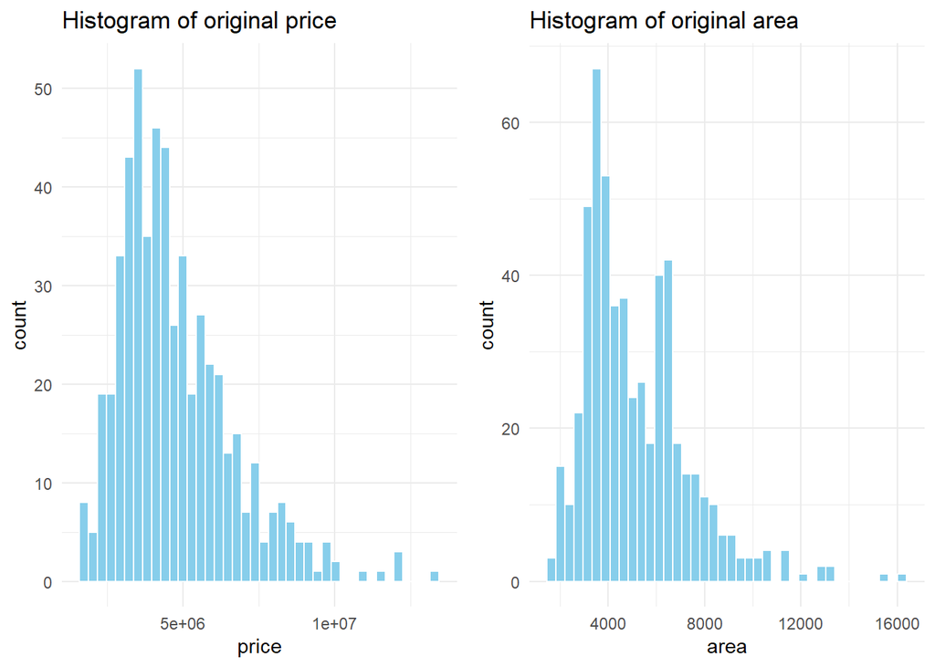

```r
plots <- list()

for (col in cols_num) {
  p <- ggplot(house, aes(x = .data[[col]])) +
    geom_histogram(bins = 40, fill = "skyblue", color = "white") +
    labs(title = paste("Histogram of original", col)) +
    theme_minimal()

  plots[[col]] <- p
}

grid.arrange(grobs = plots, ncol = 2) # Arrange all plots in a 1x2 grid
```

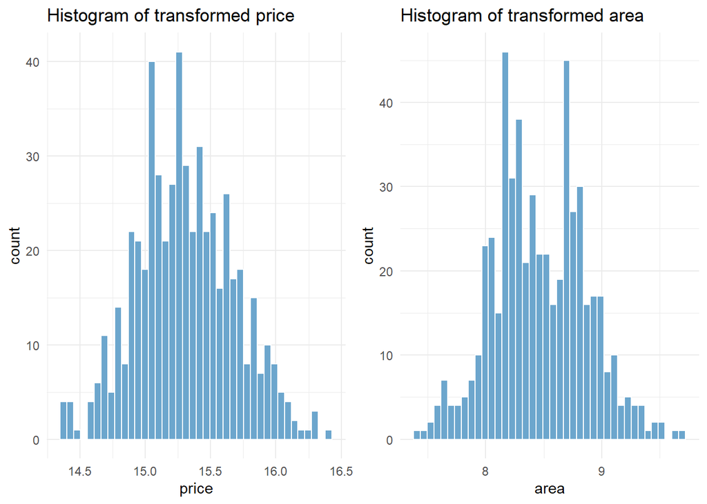

```r
plots <- list()

for (col in cols_num) {
  p <- ggplot(house_v2, aes(x = .data[[col]])) +
    geom_histogram(bins = 40, fill = "skyblue3", color = "white") +
    labs(title = paste("Histogram of transformed", col)) +
    theme_minimal()

  plots[[col]] <- p
}

grid.arrange(grobs = plots, ncol = 2) # Arrange all plots in a 1x2 grid
```

### 3.2 Distribution of categorical/factor variables

The categorical variables reveal clear structural patterns in the housing stock. Most properties have three bedrooms (55%) and one bathroom (74%), indicating a predominance of moderately sized homes. Single- and two-story houses dominate the sample (42% and 44%, respectively). Most homes are located on the main road (86%), and the majority lack a guestroom (82%) and basement (65%). Hot water heating is rare (5%), while air conditioning is present in about one-third of homes (32%). Parking availability varies, with 55% offering no dedicated parking. A large share of homes (77%) lack a preferred area designation. Furnishing is fairly balanced, with 42% semi-furnished, 33% unfurnished, and 26% furnished. Overall, the dataset reflects primarily modest, functional homes with limited luxury amenities.

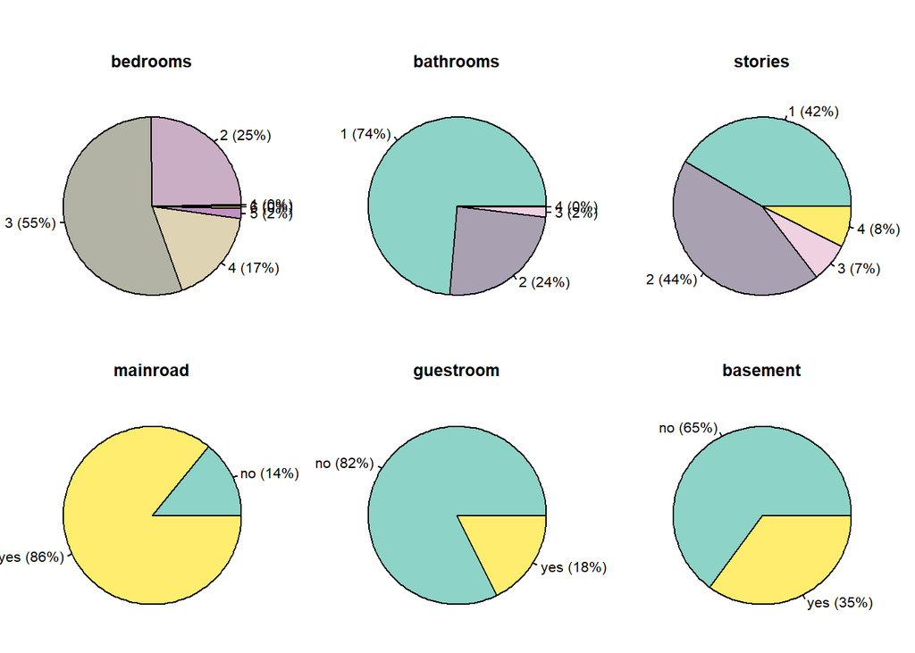

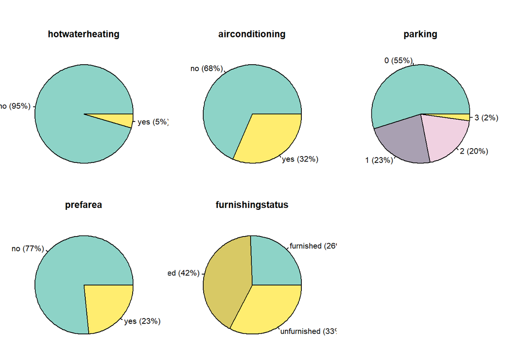

```r
cols_pie <- c('bedrooms', 'bathrooms', 'stories', 'mainroad', 'guestroom', 'basement','hotwaterheating','airconditioning','parking','prefarea','furnishingstatus')

par(mfrow = c(2, 3),
    #smaller margins
    mar   = c(1, 1, 3, 1),
    oma   = c(0, 0, 2, 0))

for (col in cols_pie) {
  counts <- table(house_v2[[col]])
  pct    <- round(100 * counts / sum(counts))
  lbls   <- paste0(names(counts), " (", pct, "%)") #format labels
  pal <- colorRampPalette(brewer.pal(12, "Set3"))(length(counts)) #color palette
  pie(counts, labels = lbls, main   = col, col    = pal)
}
```

### 3.3 Box plot `price` vs `categorical predictors`

The box plots summarize how key categorical housing features relate to the log-transformed house price. **Structural characteristics,** like the number of **bedrooms, bathrooms, and stories,** show a clear positive association with price, with median prices rising consistently across categories. Properties located on the **main road**, and those with **air conditioning**, **hot water heating**, **a guestroom**, or a **basement** also exhibit noticeably higher median prices, indicating the strong impact of these amenities. In contrast, **parking capacity** beyond one space and **furnishing status** display weaker and less consistent effects on price. Overall, the results highlight that structural features and key amenities are the primary drivers of higher house prices in the dataset.

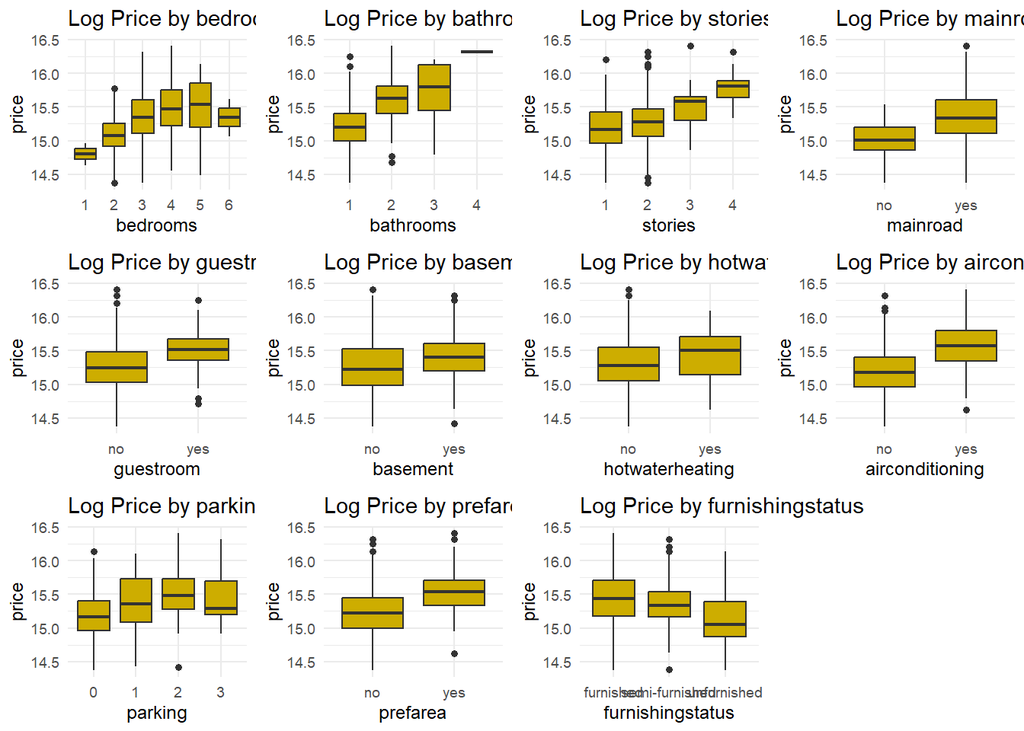

```r
cols_boxplot <- c('bedrooms', 'bathrooms', 'stories', 'mainroad', 'guestroom', 'basement','hotwaterheating','airconditioning','parking','prefarea','furnishingstatus')

plot_list <- list()

for (col in cols_boxplot) {
  p <- ggplot(house_v2, aes_string(x = col, y = "price")) +
    geom_boxplot(fill = "gold3") +
    labs(title = paste("Log Price by", col)) +
    theme_minimal(base_size = 9)

  plot_list[[col]] <- p
}

grid.arrange(grobs = plot_list, ncol = 4)
```

### 3.4 Scatter Plotting for `Price` vs `Area`

The scatter plots show a clear positive relationship between **area** and **price**, indicating that larger properties tend to command higher prices. In the original scale, the association is moderately strong with some dispersion, while the log transformations produces a tighter, more linear pattern and stabilizes variability. This confirms that **area is a strong and meaningful predictor of price**, supports the use of linear regression, and helps identify potential outliers. Overall, the fitted regression line highlights a clear linear effect of area on price after transformation.

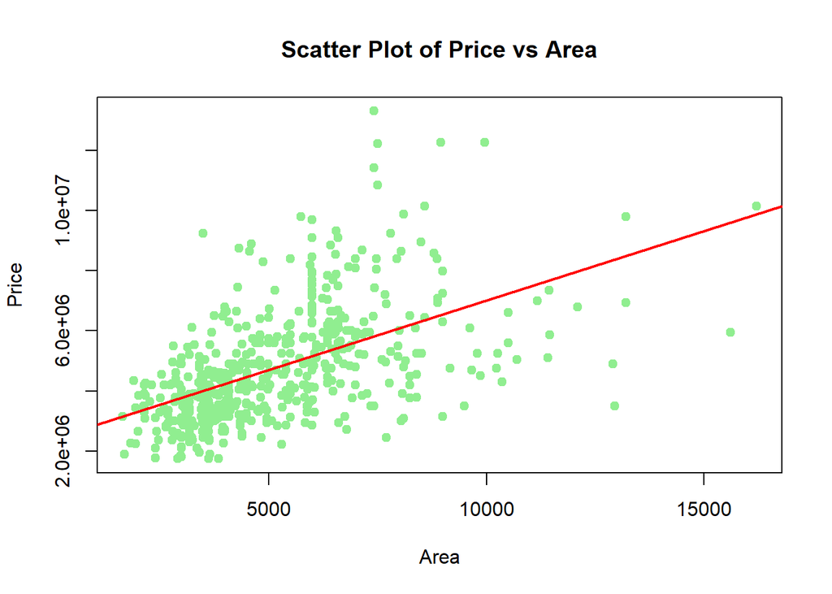

```r
plot(house$area, house$price,
     main = "Scatter Plot of Price vs Area",
     xlab = "Area",
     ylab = "Price",
     pch = 19,
     col = "lightgreen")
abline(lm(price ~ area, data = house), col = "red", lwd = 2)
```

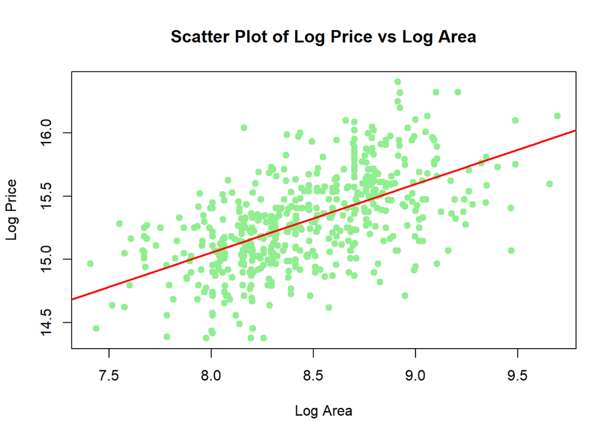

```r
plot(house_v2$area, house_v2$price,
     main = "Scatter Plot of Log Price vs Log Area",
     xlab = "Log Area",
     ylab = "Log Price",
     pch = 19,
     col = "lightgreen")
abline(lm(price ~ area, data = house_v2), col = "red", lwd = 2)
```

### 3.5 Correlation Matrix

The correlation matrix provides an assessment of how housing features relate to the log-transformed price. While correlations do not imply causation, they help identify influential predictors for model selection. The key findings are summarized below.

#### **1. Size and Structural Features**

- **Area** shows a **strong positive correlation (r=0.58)** with price, making it the most important predictor.
- **Number of stories** displays an overall **moderate positive relationship (0 to 0.36)**, indicating higher prices for multi-story homes.
- **Number of Bedrooms** show a **weak positive association (-0.37 to 0.22)**, meaning bedroom count alone is not a strong predictor compared to others.

#### **2. Home Quality and Amenities**

- **Bathrooms** have a **moderate positive correlation (0.12 to 0.44)** with price. Homes with two or more bathrooms tend to be priced notably higher.
- **Air conditioning** also has a **moderate positive association (~0.46)**, indicating that AC is a valuable feature in pricing.
- **Parking spaces** show a **weak to moderate positive correlation (0.13–0.30)**, meaning additional parking contributes to higher prices but not as strongly as interior features.

#### **3. Location and Accessibility**

- **Main road access** and **preferred area** exhibit **moderate positive correlation (~0.33 and ~0.34)**, , highlighting the importance of location in pricing.

#### **4. Additional Features**

- **Guestroom (~0.28)**, **basement (~0.22)** show modest positive correlations with price, referring that these features also impact on the price of the house.
- **Hotwaterheating (~0.09)** shows **weak correlations**, indicating limited independent effect on price.

#### **5. Furnishing Status**

- **Semi-furnished** and **furnished** homes show a **weak to moderate positive relationship** with price.
- **Unfurnished** homes display a **negative correlation**, suggesting that furnished or semi-furnished properties tend to be valued higher than unfurnished ones.

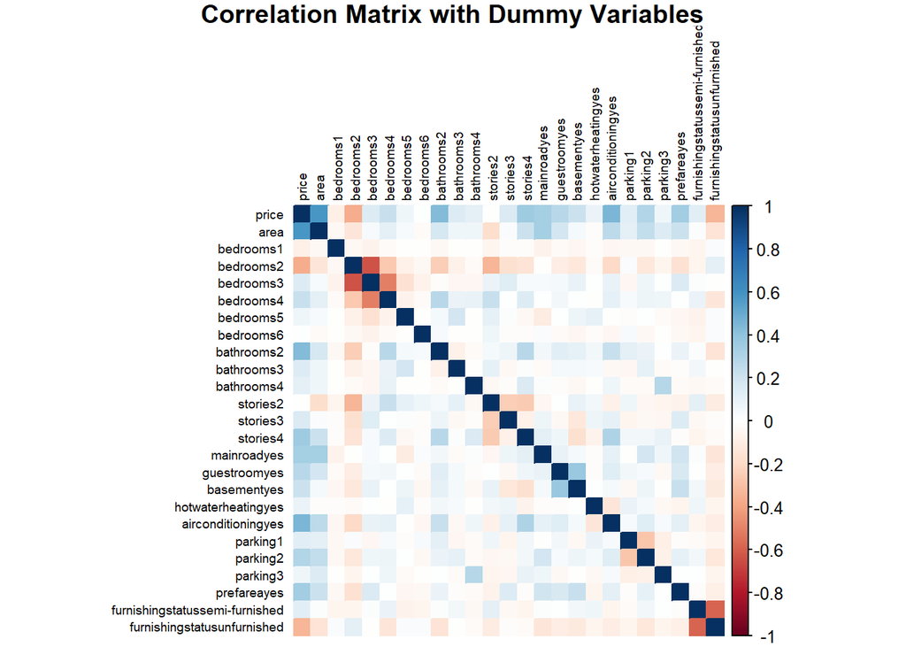

```r
# Convert factors to dummy variables
df_dummies <- model.matrix(~ . - 1, data = house_v2)
cor_matrix <- cor(df_dummies, use = "pairwise.complete.obs")

corrplot(cor_matrix,
         method = "color",
         addCoef.col = NULL,
         tl.cex = 0.6,
         tl.col = "black",
         title = "Correlation Matrix with Dummy Variables",
         mar = c(0,0,1,0))
```

### 3.6 EDA Conclusion

The EDA indicates that home size, number of bathrooms, air conditioning, number of stories, and location-related factors (main road access and preferred area) exhibit the strongest positive associations with housing prices. Additional features such as a guestroom and basement also show meaningful positive effects. In contrast, hot water heating shows only a weak relationship, while unfurnished status is negatively associated with price. These findings help prioritize key predictors for modeling and clarify which housing attributes contribute most to price variation.

## 4. Data Split

### 4.1 Train/Test Data Split

A 60/40 train–test split was created using a fixed seed for reproducibility. This ensures that the model is trained on one portion of the data while performance is evaluated on an independent subset.

```r
# Set seed for reproducibility
set.seed(1)

# Create training (60%) and testing (40%)
train_index <- createDataPartition(house_v2$price, p = 0.6, list = FALSE)
train_data <- house_v2[train_index, ]
test_data <- house_v2[-train_index, ]

x_train <- model.matrix(price ~ ., data = train_data)[, -1]
y_train <- train_data$price

x_test  <- model.matrix(price ~ ., data = test_data)[, -1]
y_test  <- test_data$price

# Performance function to compare models
model_performance <- function(actual, predicted) {
postResample(pred = predicted, obs = actual)
}
```

```r
# to check the split dataset class by using 'concatenate and print' function cat()
cat("Class of train_data:==>",class(train_data),'\n')
```

```
## Class of train_data:==> data.frame
```

```r
cat("Class of train_data:==>",class(test_data),'\n')
```

```
## Class of train_data:==> data.frame
```

```r
cat("Class of train_data:==>",class(x_train),'\n')
```

```
## Class of train_data:==> matrix array
```

```r
cat("Class of train_data:==>",class(y_train),'\n')
```

```
## Class of train_data:==> numeric
```

```r
cat("Class of train_data:==>",class(x_test),'\n')
```

```
## Class of train_data:==> matrix array
```

```r
cat("Class of train_data:==>",class(y_test),'\n')
```

```
## Class of train_data:==> numeric
```

## 5. Modeling

### 5.1 Multiple Linear Regression

```r
lm_model <- lm(price ~ ., data = train_data)
summary(lm_model)
```

```
##
## Call:
## lm(formula = price ~ ., data = train_data)
##
## Residuals:
##      Min       1Q   Median       3Q      Max
## -0.57461 -0.12771  0.00442  0.13185  0.56580
##
## Coefficients:
##                                 Estimate Std. Error t value Pr(>|t|)
## (Intercept)                    12.171565   0.318117  38.261  < 2e-16 ***
## area                            0.319953   0.034929   9.160  < 2e-16 ***
## bedrooms2                       0.046495   0.148707   0.313 0.754750
## bedrooms3                       0.087684   0.149680   0.586 0.558436
## bedrooms4                       0.066428   0.153827   0.432 0.666166
## bedrooms5                       0.085001   0.166151   0.512 0.609308
## bedrooms6                       0.385387   0.256778   1.501 0.134427
## bathrooms2                      0.177615   0.029952   5.930 8.20e-09 ***
## bathrooms3                      0.310469   0.107900   2.877 0.004293 **
## bathrooms4                      0.655195   0.230630   2.841 0.004802 **
## stories2                        0.110445   0.030410   3.632 0.000330 ***
## stories3                        0.223582   0.050663   4.413 1.42e-05 ***
## stories4                        0.252520   0.056907   4.437 1.27e-05 ***
## mainroadyes                     0.099151   0.039010   2.542 0.011527 *
## guestroomyes                    0.059421   0.034126   1.741 0.082657 .
## basementyes                     0.087442   0.027016   3.237 0.001342 **
## hotwaterheatingyes              0.088541   0.059593   1.486 0.138372
## airconditioningyes              0.170539   0.028265   6.034 4.64e-09 ***
## parking1                        0.107845   0.030716   3.511 0.000514 ***
## parking2                        0.077735   0.032125   2.420 0.016114 *
## parking3                       -0.006102   0.088093  -0.069 0.944821
## prefareayes                     0.119490   0.029633   4.032 6.98e-05 ***
## furnishingstatussemi-furnished  0.003007   0.029492   0.102 0.918843
## furnishingstatusunfurnished    -0.099554   0.031174  -3.193 0.001553 **
## ---
## Signif. codes:  0 '***' 0.001 '**' 0.01 '*' 0.05 '.' 0.1 ' ' 1
##
## Residual standard error: 0.206 on 305 degrees of freedom
## Multiple R-squared:  0.7227, Adjusted R-squared:  0.7018
## F-statistic: 34.56 on 23 and 305 DF,  p-value: < 2.2e-16
```

```r
lm_pred <- predict(lm_model, newdata = test_data)
lm_perf <- model_performance(y_test, lm_pred)
lm_perf
```

```
##      RMSE  Rsquared       MAE
## 0.2068810 0.6797041 0.1547581
```

```r
vif(lm_model) #check multicollinearity
```

```
##                      GVIF Df GVIF^(1/(2*Df))
## area             1.561846  1        1.249738
## bedrooms         2.223220  5        1.083174
## bathrooms        1.676105  3        1.089892
## stories          2.417776  3        1.158518
## mainroad         1.260442  1        1.122694
## guestroom        1.239107  1        1.113152
## basement         1.311501  1        1.145208
## hotwaterheating  1.122092  1        1.059288
## airconditioning  1.332453  1        1.154319
## parking          1.573415  3        1.078468
## prefarea         1.242544  1        1.114695
## furnishingstatus 1.174134  2        1.040949
```

### 5.2 MLR+ interactions

Similar as the previous model, the regression model with the `area × guestroom` interaction is highly significant (F=33.34, p<2.2e−16) and explains a large share of the variation in house prices (R²=0.7247, Adj. R²=0.7029). Area remains the strongest predictor of price, while bathrooms, number of stories, main road access, air conditioning, parking (1 and 2 spaces), and preferred area also have significant positive effects. Basement remains significant, but guestroom and area–guestroom interaction are not significant. The model shows good predictive accuracy (RMSE=0.2051 MAE=0.1536).

```r
lm_int_model <- lm(price ~ . + area*guestroom, data = train_data)
summary(lm_int_model)
```

```
##
## Call:
## lm(formula = price ~ . + area * guestroom, data = train_data)
##
## Residuals:
##      Min       1Q   Median       3Q      Max
## -0.58385 -0.11554  0.00203  0.12204  0.58184
##
## Coefficients:
##                                 Estimate Std. Error t value Pr(>|t|)
## (Intercept)                    12.048987   0.328063  36.728  < 2e-16 ***
## area                            0.335001   0.036305   9.227  < 2e-16 ***
## bedrooms2                       0.041291   0.148456   0.278 0.781094
## bedrooms3                       0.089299   0.149390   0.598 0.550446
## bedrooms4                       0.071573   0.153564   0.466 0.641495
## bedrooms5                       0.086958   0.165830   0.524 0.600397
## bedrooms6                       0.393289   0.256328   1.534 0.125992
## bathrooms2                      0.174307   0.029976   5.815 1.53e-08 ***
## bathrooms3                      0.307853   0.107703   2.858 0.004553 **
## bathrooms4                      0.649988   0.230204   2.824 0.005063 **
## stories2                        0.107315   0.030424   3.527 0.000485 ***
## stories3                        0.221009   0.050593   4.368 1.72e-05 ***
## stories4                        0.247815   0.056883   4.357 1.81e-05 ***
## mainroadyes                     0.094368   0.039067   2.416 0.016301 *
## guestroomyes                    1.323220   0.852393   1.552 0.121617
## basementyes                     0.088624   0.026974   3.285 0.001137 **
## hotwaterheatingyes              0.089491   0.059479   1.505 0.133469
## airconditioningyes              0.171884   0.028224   6.090 3.41e-09 ***
## parking1                        0.108174   0.030656   3.529 0.000482 ***
## parking2                        0.080255   0.032106   2.500 0.012958 *
## parking3                       -0.012263   0.088018  -0.139 0.889287
## prefareayes                     0.116637   0.029637   3.936 0.000103 ***
## furnishingstatussemi-furnished  0.004482   0.029451   0.152 0.879148
## furnishingstatusunfurnished    -0.096894   0.031164  -3.109 0.002054 **
## area:guestroomyes              -0.146273   0.098577  -1.484 0.138889
## ---
## Signif. codes:  0 '***' 0.001 '**' 0.01 '*' 0.05 '.' 0.1 ' ' 1
##
## Residual standard error: 0.2056 on 304 degrees of freedom
## Multiple R-squared:  0.7247, Adjusted R-squared:  0.7029
## F-statistic: 33.34 on 24 and 304 DF,  p-value: < 2.2e-16
```

```r
lm_int_pred <- predict(lm_int_model, newdata = test_data)
lm_int_perf <- model_performance(y_test, lm_int_pred)
lm_int_perf
```

```
##      RMSE  Rsquared       MAE
## 0.2051259 0.6849389 0.1536228
```

### 5.3 LASSO

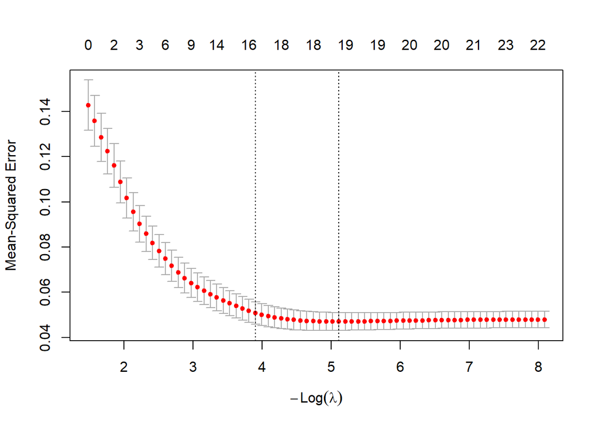

```r
set.seed(1)
# LASSO
lasso_cv <- cv.glmnet(x_train,
                      y_train,
                      alpha = 1,
                      nfolds = 10
                     )

plot(lasso_cv)
```

```r
lasso_model <- glmnet(x_train,
                      y_train,
                      alpha = 1,
                      lambda = lasso_cv$lambda.min
                      )

# Extract coefficients at optimal lambda
lasso_coef <- coef(lasso_model)
lasso_selected <- lasso_coef[lasso_coef[, 1] != 0, , drop = FALSE]
lasso_selected
```

```
## 19 x 1 sparse Matrix of class "dgCMatrix"
##                                      s0
## (Intercept)                 12.31766726
## area                         0.31715657
## bedrooms2                   -0.04901157
## bedrooms6                    0.18680047
## bathrooms2                   0.17421878
## bathrooms3                   0.26618989
## bathrooms4                   0.53194014
## stories2                     0.08485621
## stories3                     0.18756914
## stories4                     0.21627726
## mainroadyes                  0.09483715
## guestroomyes                 0.05502195
## basementyes                  0.07673824
## hotwaterheatingyes           0.06328742
## airconditioningyes           0.16504909
## parking1                     0.09309006
## parking2                     0.06214272
## prefareayes                  0.11141780
## furnishingstatusunfurnished -0.09346091
```

```r
lasso_pred <- predict(lasso_model, newx = x_test)
lasso_perf <- model_performance(y_test, as.numeric(lasso_pred))
lasso_perf
```

```
##      RMSE  Rsquared       MAE
## 0.2062783 0.6798335 0.1529950
```

### 5.4 Ridge

Ridge regression was tuned using 10-fold cross-validation to select the optimal penalty parameter. Using the optimal λ, the Ridge model achieves a test RMSE=0.2042, R² =0.6864, and MAE =0.1515, demonstrating good predictive performance that is slightly better than the standard multiple linear regression model but comparable to LASSO. Unlike LASSO, Ridge retains all predictors with shrunk coefficients, confirming that no variable is fully removed from the model. The largest positive effects remain associated with area, number of bathrooms, number of stories, air conditioning, preferred area, main road access, basement, and parking (1 and 2 spaces). Overall, Ridge improves coefficient stability through shrinkage but does not provide substantial gains in predictive accuracy compared with the simpler linear and LASSO models.

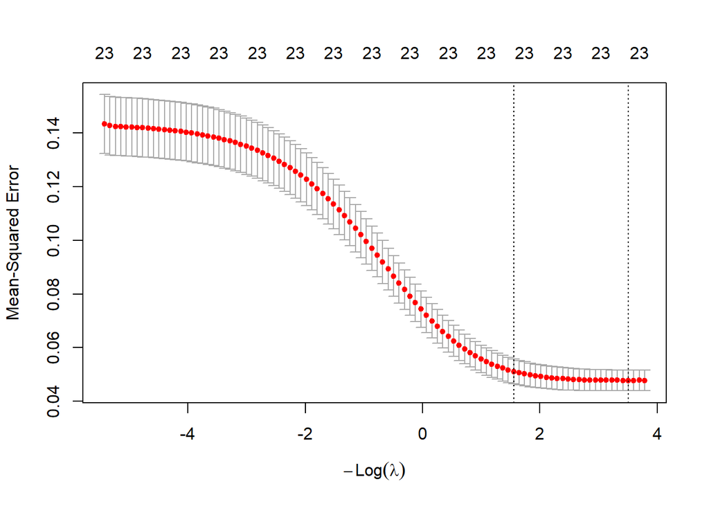

```r
set.seed(1)
# Ridge
ridge_cv <- cv.glmnet(x_train,
                      y_train,
                      alpha = 0,
                      nfolds = 10
                      )

plot(ridge_cv)
```

```r
ridge_model <- glmnet(x_train,
                      y_train,
                      alpha = 0,
                      lambda = ridge_cv$lambda.min
                      )

# Extract coefficients at optimal lambda
ridge_coef <- coef(ridge_model)
ridge_selected <- ridge_coef[ridge_coef[, 1] != 0, , drop = FALSE]
ridge_selected
```

```
## 24 x 1 sparse Matrix of class "dgCMatrix"
##                                          s0
## (Intercept)                    12.471426828
## area                            0.292860065
## bedrooms2                      -0.028929468
## bedrooms3                       0.030189384
## bedrooms4                       0.021945883
## bedrooms5                       0.040254469
## bedrooms6                       0.311442089
## bathrooms2                      0.169718982
## bathrooms3                      0.289117877
## bathrooms4                      0.607730927
## stories2                        0.085266963
## stories3                        0.194659446
## stories4                        0.226732114
## mainroadyes                     0.108303116
## guestroomyes                    0.066390405
## basementyes                     0.079184030
## hotwaterheatingyes              0.084406586
## airconditioningyes              0.162877798
## parking1                        0.105476324
## parking2                        0.077667065
## parking3                        0.008638358
## prefareayes                     0.116602827
## furnishingstatussemi-furnished  0.005831265
## furnishingstatusunfurnished    -0.093627198
```

```r
ridge_pred <- predict(ridge_model, newx = x_test)
ridge_perf <- model_performance(y_test, as.numeric(ridge_pred))
ridge_perf
```

```
##      RMSE  Rsquared       MAE
## 0.2041707 0.6863529 0.1515471
```

### 5.5 Elastic Net

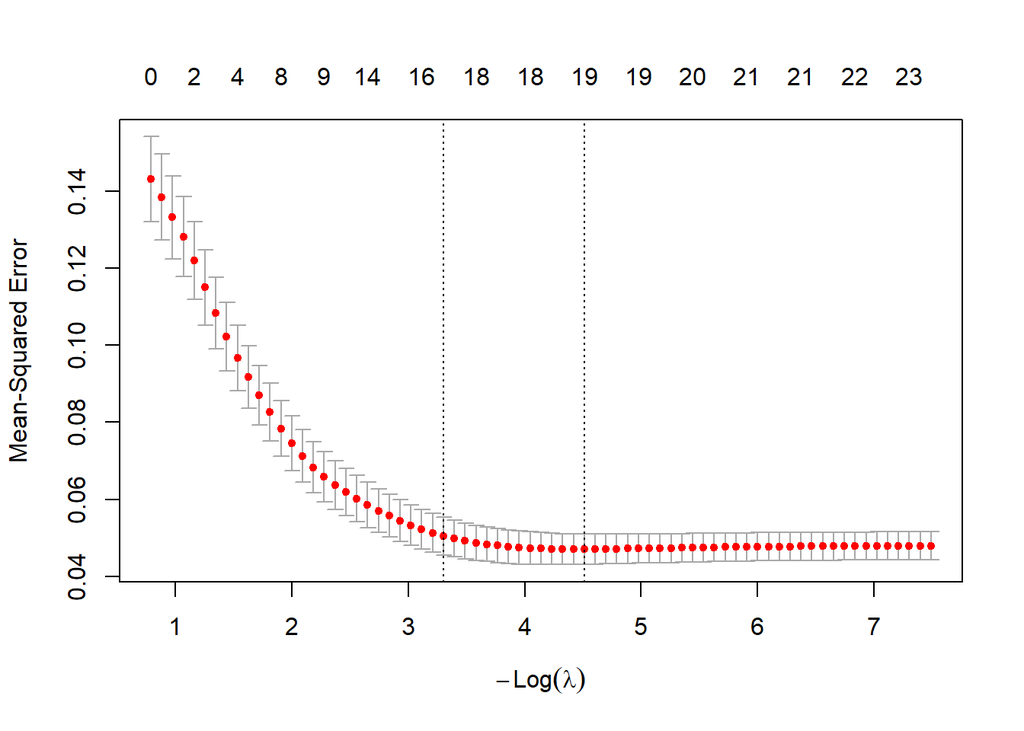

```r
set.seed(1)
# mix of LASSO and Ridge
elastic_cv <- cv.glmnet(x_train,
                        y_train,
                        alpha = 0.5,
                        nfolds = 10
                        )

plot(elastic_cv)
```

```r
elastic_model <- glmnet(x_train,
                        y_train,
                        alpha = 0.5,
                        lambda = elastic_cv$lambda.min
                        )

# Extract coefficients at optimal lambda
elastic_coef <- coef(elastic_model)
elastic_selected <- elastic_coef[elastic_coef[, 1] != 0, , drop = FALSE]
elastic_selected
```

```
## 20 x 1 sparse Matrix of class "dgCMatrix"
##                                        s0
## (Intercept)                 12.3589642773
## area                         0.3121942365
## bedrooms2                   -0.0510031293
## bedrooms3                    0.0002435909
## bedrooms6                    0.1948609919
## bathrooms2                   0.1731238193
## bathrooms3                   0.2669571899
## bathrooms4                   0.5375564309
## stories2                     0.0829547373
## stories3                     0.1858354459
## stories4                     0.2152121647
## mainroadyes                  0.0968771207
## guestroomyes                 0.0567178162
## basementyes                  0.0762914101
## hotwaterheatingyes           0.0651248273
## airconditioningyes           0.1641841030
## parking1                     0.0940627412
## parking2                     0.0637707403
## prefareayes                  0.1116470131
## furnishingstatusunfurnished -0.0934841876
```

```r
elastic_pred <- predict(elastic_model, newx = x_test)
elastic_perf <- model_performance(y_test, as.numeric(elastic_pred))
elastic_perf
```

```
##      RMSE  Rsquared       MAE
## 0.2058850 0.6810847 0.1526464
```

### 5.6 Random Forest

```r
set.seed(1)

train_control <- trainControl(method = "cv", number = 10, savePredictions = "final")

rf_cv_model <- train(price ~ .,
                     data = train_data,
                     method = "rf",
                     trControl = train_control,
                     ntree = 500,          # Passed to randomForest
                     importance = TRUE)    # Passed to randomForest

# CV Results
print(rf_cv_model$results)
```

```
##   mtry      RMSE  Rsquared       MAE     RMSESD RsquaredSD      MAESD
## 1    2 0.2421490 0.6638446 0.1827149 0.02959599  0.1023566 0.02138461
## 2   12 0.2280788 0.6354898 0.1760562 0.04212961  0.1292643 0.03166115
## 3   23 0.2337346 0.6165172 0.1788302 0.04654764  0.1412554 0.03382702
```

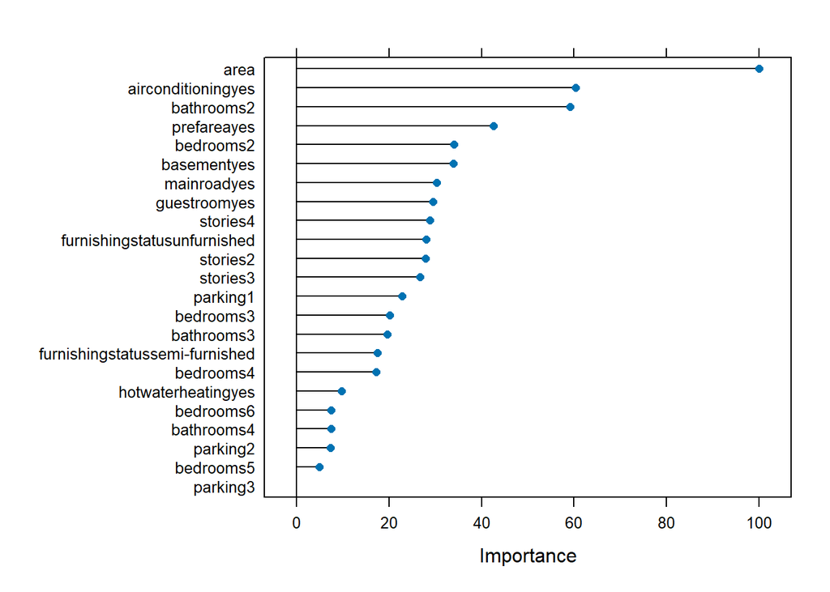

```r
# variable importance
plot(varImp(rf_cv_model))
```

```r
# Final prediction
rf_pred <- predict(rf_cv_model, newdata = test_data)
rf_perf <- model_performance(test_data$price, rf_pred)
rf_perf
```

```
##      RMSE  Rsquared       MAE
## 0.2247171 0.6213959 0.1663650
```

### 5.7 Gradient Boosting

The Gradient Boosting model identifies `area` as the most dominant predictor of house price, accounting for ≈49% of the total relative influence . The next most influential predictors are bathrooms, air conditioning, stories, and parking, highlighting the strong role of both structural features and key amenities in determining housing value. The GBM achieves a test RMSE=0.252, R²=0.580, and MAE=0.193, which is notably weaker than the regression-based and regularized models. This suggests that, despite capturing nonlinear relationships and interactions, the Gradient Boosting model does not generalize as well on this dataset.

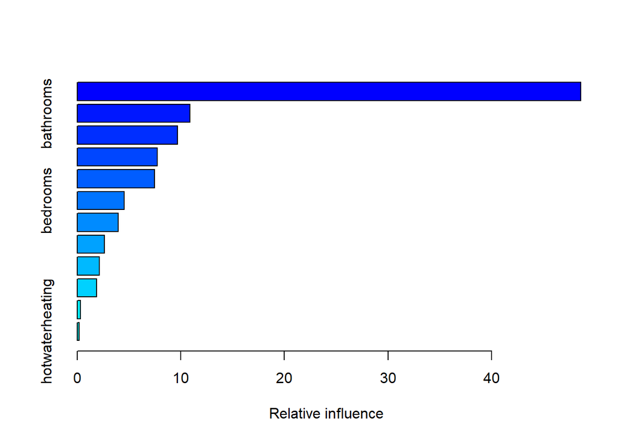

```
##                               var    rel.inf
## area                         area 48.5996720
## bathrooms               bathrooms 10.8962431
## airconditioning   airconditioning  9.6706642
## stories                   stories  7.7386370
## parking                   parking  7.4519788
## bedrooms                 bedrooms  4.5245775
## furnishingstatus furnishingstatus  3.9703341
## prefarea                 prefarea  2.6435386
## guestroom               guestroom  2.1176310
## basement                 basement  1.8787227
## mainroad                 mainroad  0.3090312
## hotwaterheating   hotwaterheating  0.1989698
```

```r
set.seed(1)

gbm_model <- gbm(
  formula = price ~ .,
  data = train_data,
  distribution = "gaussian",
  n.trees = 2000,
  interaction.depth = 3,
  shrinkage = 0.01,
  n.minobsinnode = 10,
  bag.fraction = 0.8,
  train.fraction = 0.8,
  cv.folds = 10,         # 10-fold CV
  verbose = FALSE
)

summary(gbm_model)
```

```r
best_iter <- gbm.perf(gbm_model, method = "cv", plot.it = FALSE)
gbm_pred <- predict(gbm_model, newdata = test_data, n.trees = best_iter)

gbm_perf <- model_performance(test_data$price, gbm_pred)
gbm_perf
```

```
##      RMSE  Rsquared       MAE
## 0.2521828 0.5803659 0.1933094
```

## 6. Interpretation and Model Selection

### 6.1 Model Comparison

he comparison results indicate that all linear and regularized regression models perform competitively, with relatively close RMSE, R², and MAE values. Among them, Ridge regression achieves the lowest RMSE (0.2042) and highest R² (0.6864), indicating the strongest overall predictive performance. The Linear model with interactions and the Elastic Net follow very closely, suggesting that they provide only marginal improvements over the baseline linear structure.

The LASSO and standard MLR models also show similar predictive accuracy, confirming that the relationship between predictors and house price is largely well explained through linear effects. In contrast, the Random Forest and especially the Gradient Boosting models perform noticeably worse, with higher RMSE values and lower R². This suggests that complex nonlinear models do not offer an advantage for this dataset.

```r
model_results <- bind_rows(
  data.frame(Model = "Linear",        t(lm_perf)),
  data.frame(Model = "Linear + Interactions", t(lm_int_perf)),
  data.frame(Model = "LASSO",         t(lasso_perf)),
  data.frame(Model = "Ridge",         t(ridge_perf)),
  data.frame(Model = "Elastic Net",   t(elastic_perf)),
  data.frame(Model = "Random Forest", t(rf_perf)),
  data.frame(Model = "Gradient Boosting", t(gbm_perf))
)

model_results <- model_results %>% arrange(RMSE)   # lower RMSE is better

model_results
```

```
##                   Model      RMSE  Rsquared       MAE
## 1                 Ridge 0.2041707 0.6863529 0.1515471
## 2 Linear + Interactions 0.2051259 0.6849389 0.1536228
## 3           Elastic Net 0.2058850 0.6810847 0.1526464
## 4                 LASSO 0.2062783 0.6798335 0.1529950
## 5                Linear 0.2068810 0.6797041 0.1547581
## 6         Random Forest 0.2247171 0.6213959 0.1663650
## 7     Gradient Boosting 0.2521828 0.5803659 0.1933094
```

### 6.2 Selected model

Based on the overall performance metrics and model behavior, **Ridge regression is selected as the final predictive model.**

- This choice is driven by its superior predictive accuracy, showed by the lowest RMSE and highest R² among all methods.
- It provides stable coefficient estimates through shrinkage, effectively mitigating the potential effects of multicollinearity without removing important predictors from the model.
- Compared to LASSO and Elastic Net, Ridge achieves slightly better predictive performance while retaining all relevant features, supporting more comprehensive interpretation.
- When compared with machine-learning models, Ridge offers substantial advantages in terms of interpretability and stability.

These qualities make Ridge regression a reliable and well-balanced choice for the final model.

### 6.3 Conclusion:

This analysis demonstrates that regularized linear modeling is the most effective for predicting house prices in the dataset. Although more complex models such as Random Forest and Gradient Boosting are capable of capturing nonlinear relationships and interaction effects, they do not outperform simpler linear approaches in terms of predictive accuracy on this dataset. The results indicate that house price variation is primarily driven by linear effects related to property size, structural characteristics, key amenities, and location attributes. Among all the models evaluated, **Ridge regression** emerges as the best-performing and most reliable option, offering the optimal balance between accuracy, robustness, and interpretability.

### 6.4 Next steps

We consider that the current modeling can be improved and strengthened through the following:

- Incorporate additional external and spatial variables, such as public transport accessibility, school rankings, and neighborhood safety, to better capture location-driven price effects and enhance predictive accuracy.
- Use time-series housing data to enable price forecasting, market trend analysis, providing deeper insight into how housing prices evolve over time.